# Item Pool Visualization

Nils Petras

2022-09-30

## About this package

The IPV package is a tool to create IPV charts. The original work on IPV, including the chart concepts, can be found in: [Dantlgraber, M., Stieger, S., & Reips, U. D. (2019). Introducing Item Pool Visualization: A method for investigation of concepts in self-reports and psychometric tests. Methodological Innovations, 12(3), 2059799119884283.](https://doi.org/10.1177/2059799119884283). Please cite this paper, as well as this package (Petras, N., & Dantlgraber, M. (2022). IPV: Item Pool visualization. R Package Version 1.0.0) when using the package. The package is built to enable chart creation – quick & dirty or highly customized. Please raise an [issue on github](https://github.com/NilsPetras/IPV/issues) in case of bugs or to make suggestions.

### Example data

The package contains two sets of example data:

1. The model estimates from the original IPV paper `?self_confidence` (also available as excel spreadsheets, see Appendix)
2. Raw data from the [Open-Source Psychometrics Project](https://openpsychometrics.org/) `?HEXACO`

### Terminology within the package

IPV uses the concept of item pools, that can be divided into smaller item (sub-)pools. The hierarchy of terms for item pools in this package is “construct” > “test” > “facet”, from large to small. The total item pool of a (psychological) construct may comprise multiple tests, which in turn may comprise multiple facets. This terminology is based on the common data structure in psychological assessment. But IPV can technically be used for any subdivision of an item pool, if multiple levels of specificity exist (see Dantlgraber et al., 2019). In other words, what is called “test” here does not need to be an actual test, etc.

## Recommended Workflow

1. Prepare your raw data.
2. Generate the model estimates using `ipv_est()`.
3. Select a chart function and use it with the estimates, a file name, and otherwise default values.
4. Customize the appearance using further arguments of the chart function.
5. Check the chart’s appearance by opening the created file.
6. Repeat 4. + 5. until you are satisfied with the result.

Minimal example:

```r
mydata <- HEXACO[ ,c(2:41, 122:161)] # (1.) HEXACO is a data frame containing raw data
res <- ipv_est(mydata, name = "HA") # (2.) produce a formatted bundle of estimates to use
nested_chart(res, file_name = "test.pdf") # (3.) create a chart with default formatting
```

There are some additional helper functions, such as the `input_...` functions, which enable you to format already existing model estimates.

Call `?IPV` for an overview of all functions.

### 1. Prepare data

The `ipv_est()` function is recommended for model estimation, because it only needs raw data. It automatically estimates the models underlying IPV charts. Its output can be plugged into the chart functions directly.

To use this function, your data needs to be formatted as follows:

- long format:
  - columns called “test”, “facet”, and “item”, where each item is uniquely allocated to one facet of one test and each item name is unique
  - a case identifying column (e.g. “id”)
  - a column containing the (numeric) measurement values
  - tests without facets are currently only supported in wide format

For example:

```
#>   id value test facet  item
#> 1  2     2    H  Sinc Sinc1
#> 2  3     3    H  Sinc Sinc1
#> 3  4     4    H  Sinc Sinc1
#> 4  5     3    H  Sinc Sinc1
#> 5  6     3    H  Sinc Sinc1
#> 6  7     3    H  Sinc Sinc1
```

- wide format:
  - all items (indicator variables) are (numeric) columns of a data frame
  - the data frame contains only those variables used in the models (or use indexing as in the example)
  - all columns are named according to the pattern “test_facet_item”
  - all variable names are unique
  - all item names (“…_…_item”) are unique at the level of the test (not only at the level of the facet!)
  - tests without facets use the pattern “test_item”
  - in the simple case of a single test, the pattern is “facet_item”

For example:

```
#>   H_Sinc_Sinc2 H_Sinc_Sinc3 H_Sinc_Sinc4
#> 2            2            3            1
#> 3            2            2            2
#> 4            5            5            4
```

H = honesty/humility (“test”)

Sinc = sincerity (a “facet” of honesty/humility)

Sinc1 = first “item” of the sincerity facet

### 2. Generate model estimates

`ipv_est()` automatically determines if the data are in wide or long format, which models to estimate, uses the [lavaan package](https://lavaan.ugent.be/) to estimate them, and returns an object of class “IPV” with formatted results.

```r
# nested case: honesty/humility and agreeableness as "tests" (= sub-pools)
# of an overarching "construct" (= item pool)
res_HA <- ipv_est(dat = HEXACO[ ,c(2:41, 122:161)], name = "HA")
# simple case: agreeableness only
res_A <- ipv_est(dat = HEXACO[ ,c(122:161)], name = "A")
```

If any factor loading is below .1 or any center distance below 0, it is set to that value and a warning (or message) is displayed. IPV does not allow negative factor loadings, which is indicated by an error. In this case, check if you have properly recoded negatively keyed items. If there remain negative factor loadings, the data does not fulfill the requirements of IPV (Dantlgraber et al., 2019).

Results are provided as an object of the class “IPV”, which is a list containing (some of) the following elements:

- “lav”: the lavaan object for each estimated model (optional)
- “est_raw”: estimates (factor loadings, latent correlations) structured based on the item pools, (optional)
- “est”: pre-formatted list of center distances and latent correlations for IPV chart creation

You should always inspect the estimated models (“lav”) to understand what is going on with your data. Use the lavaan functions (e.g. `lavaan::fitmeasures`, `lavaan::summary`, `lavaan::lavInspect`) for this purpose.

A more thorough introduction to the formatting of the objects representing model estimates can be found in the section on the alternative workflow in the Appendix.

### 3. Create and save IPV charts

Use the chart functions (`item_chart`, `facet_chart`, `nested_chart`) to create an IPV chart from your data.

All three IPV chart types can be created by specifying `data =` only:

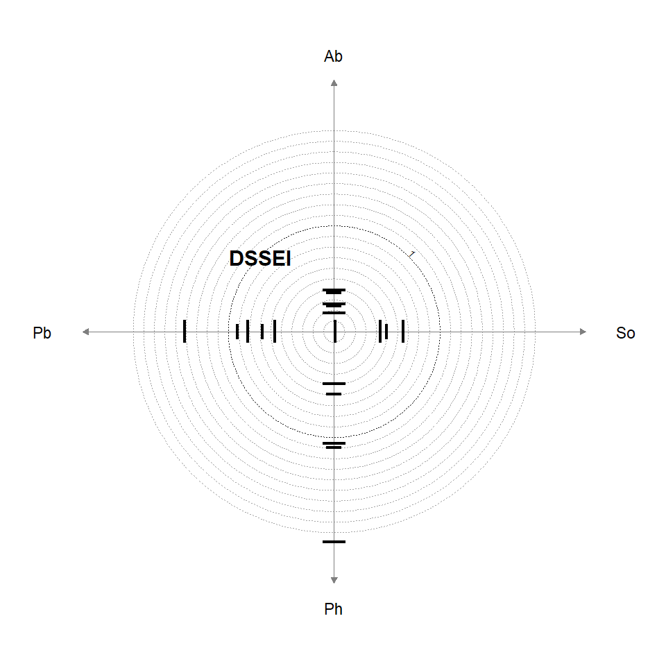

```r
mychart <- item_chart(data = self_confidence)
mychart
```

If the `test =` argument is unspecified, the first test will automatically be chosen.

It is advisable to use vector-based .pdf graphics output using the `file_name =` argument:

```r
mychart <- item_chart(data = self_confidence, test = "DSSEI", file_name = "DSSEI_item_chart.pdf")
```

.pdf files can be zoomed and scaled indefinitely without loss of quality. If you need .png or .jpeg graphics output, use the `dpi =` argument to find a balance between quality and file size. The file format provided to `file_name =` will be used. By default, no file is saved. Saving manually is not recommended.

It is advisable to inspect the graphics file itself. If you inspect your results within RStudio, always use the zoom pop-out of the Plots window, otherwise charts may be heavily distorted.

### 4. Customize IPV charts

Although some graphical options are automatically optimized based on the data, there are many ways to optimize the charts’ appearance (e.g. for print). For example you may use a different [colour](http://www.stat.columbia.edu/~tzheng/files/Rcolor.pdf) to guide attention, or re-size elements of the chart for readability.

#### 4.1 center distance method

The parameter `cd_method =` allows to switch between aggregation methods for center distances in facet charts and nested charts. There are two options:

`"aggregate"` computes the sum of the squared loadings of all items first and in a second step computes the center distance based on the aggregated values. This is the recommended option and the default. It is more meaningful in cases with heterogeneous factor loadings across items.

`"mean"` first computes the center distance of each item and in a second step computes the mean of these center distances. This is the originally proposed option (Dantlgraber et al., 2019). It can be intuitively derived from item charts.

#### 4.2. Variable labels

The function `relabel()` can be used to change any item, facet, test, or construct name, using a before-after syntax (see documentation).

#### 4.3. Size of chart elements

Most graphical parameters are size parameters for single elements of the chart, all named `size_... =`, `width_... =`, or `length_... =`. Those are pretty straightforward: linear scaling parameters defaulting to 1. That means, .5 will half the size and 2 will double it. For all chart types, there is also a global `size =` parameter, scaling all elements of the chart at once. Use this parameter first, before you fine tune single elements.

#### 4.4 Output file properties

The parameters `file_width =` and `file_height =` determine, how large the .pdf file will be, measured in inches (1 in = 2.54 cm). The size of .png or .jpeg files in pixels is determined by multiplying the size in inches with the dots per inch parameter value (`dpi =`).

#### 4.5 Showing sections of the chart (“Screenshots”)

In some cases, it may be desirable to cut the chart to the informative area for better readability, or to zoom in on a certain section of the chart. It is possible to create vector-based PDF versions of sections of the chart. The parameters `zoom_x =` and `zoom_y =` can be used to crop the chart to a certain area by providing lower and upper limits on both dimensions. The aspect ratio is automatically retained if both parameters are used. This method is superior to a manual screenshot, because it retains maximum graphics quality and is exactly reproducible.

#### 4.6. Rotation and order

For all chart types, it is possible to rotate the whole chart, using `rotate_radians =` (use fractions of $2\pi$) or `rotate_degrees =` (use 0-360). In all charts, the parameter `facet_order =` enables you to set the (counter-clockwise) order of facets. For example:

```r
item_chart(self_confidence, test = "DSSEI", facet_order = c("Ab", "So", "Ph", "Pb"))
```

In nested charts, `test_order =` and `subrotate_degrees =`/`subrotate_radians =` will function likewise. Several `rotate_... =` parameters can be used to re-position single elements of the chart relative to the origin.

#### 4.7. Font

The font can be changed using the `font =` parameter. The package extrafont allows access to many more fonts. For changes to the font size, see section 4.3.

#### 4.8. Structural elements

To reduce the visibility of structural elements, the `fade_... =` parameters can be used (0 = “black”, 100 = “white”).

#### 4.9. Colour

For the use of colours and gray tones, see [this guide](http://www.stat.columbia.edu/~tzheng/files/Rcolor.pdf). All charts functions have at least one colour parameter to increase visual contrast.

#### 4.10 Additional plot layers

The chart functions return a ggplot2 object, which can easily be combined with other geoms or entire plots. The following example uses this to show two facet charts side by side at the same scale:

```r
library(ggplot2)
library(cowplot)
x <- facet_chart(self_confidence) +
  coord_fixed(
    ratio = 1,
    ylim = c(-3, 3),
    xlim = c(-3, 3))
```

```
#> Axis tick set to 0.1 based on the data.
#> Facet circle radius set to 0.31 based on the data.
```

```r
y <- facet_chart(self_confidence, test = "RSES") +
  coord_fixed(
    ratio = 1,
    ylim = c(-3, 3),
    xlim = c(-3, 3))
```

```
#> Axis tick set to 0.05 based on the data.
#> Facet circle radius set to 0.211 based on the data.
```

```r
# Save just as any other ggplot
ggsave(filename = "test.pdf",
       plot = plot_grid(plotlist = list(x, y), align = "h"),
       width = 20, height = 10) # defaults are optimized for 10x10 inches per chart
```

#### 4.11. Special options for item charts

You can use different colors for every second item to increase readability of item charts:

```r
mychart <- item_chart(
  data = self_confidence, test = "DSSEI",
  color = "darkblue", color2 = "darkred")
mychart
```

[output not shown]

The `dodge =` parameter allows long facet labels to dodge the rest of the chart horizontally:

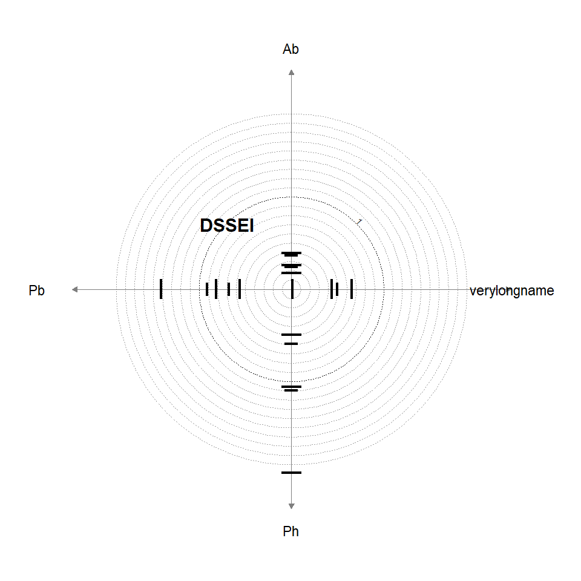

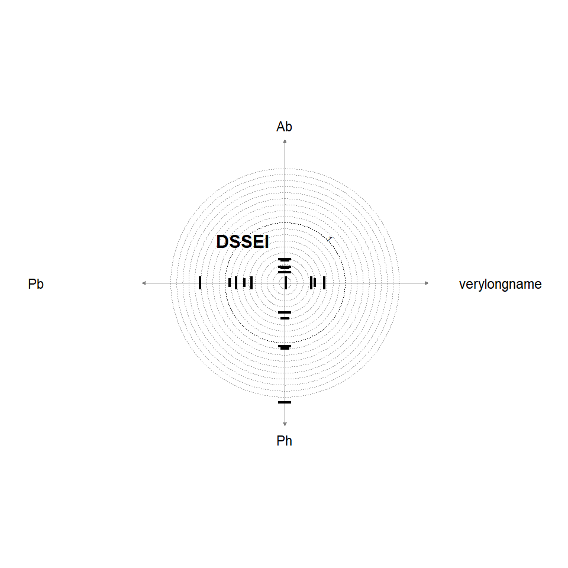

```r
x <- self_confidence
x <- relabel(x, "So", "verylongname")
mychart1 <- item_chart(data = x, test = "DSSEI")
mychart2 <- item_chart(data = x, test = "DSSEI", dodge = 7)
mychart1
mychart2
```

This works simultaneously for all labels. Labels at the top and bottom do not move, labels on the right and left move the most.

#### 4.12. Special options for facet charts

```r
mychart <- facet_chart(data = self_confidence, test = "DSSEI")
```

```
#> Axis tick set to 0.1 based on the data.
#> Facet circle radius set to 0.31 based on the data.
```

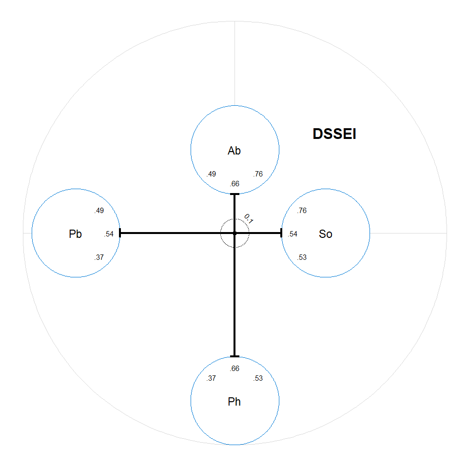

```r
mychart
```

As you can see in the output (and the message in the console), two parameter values (`subradius =` , and `tick =` ) have been generated automatically. These can be used to improve readability. `subradius =` sets the size of the facet circles and `tick =` sets the value at which a tick mark should be displayed.

For a simplistic version of the chart, the correlations can be omitted, by setting `cor_labels = FALSE`. It is also possible to omit the tick marks emphasizing the center distances by setting `size_marker = 0`.

```r
mychart <- facet_chart(
  data = self_confidence,
  test = "DSSEI",
  cor_labels = FALSE,
  size_marker = 0)
```

```
#> Axis tick set to 0.1 based on the data.
#> Facet circle radius set to 0.31 based on the data.
```

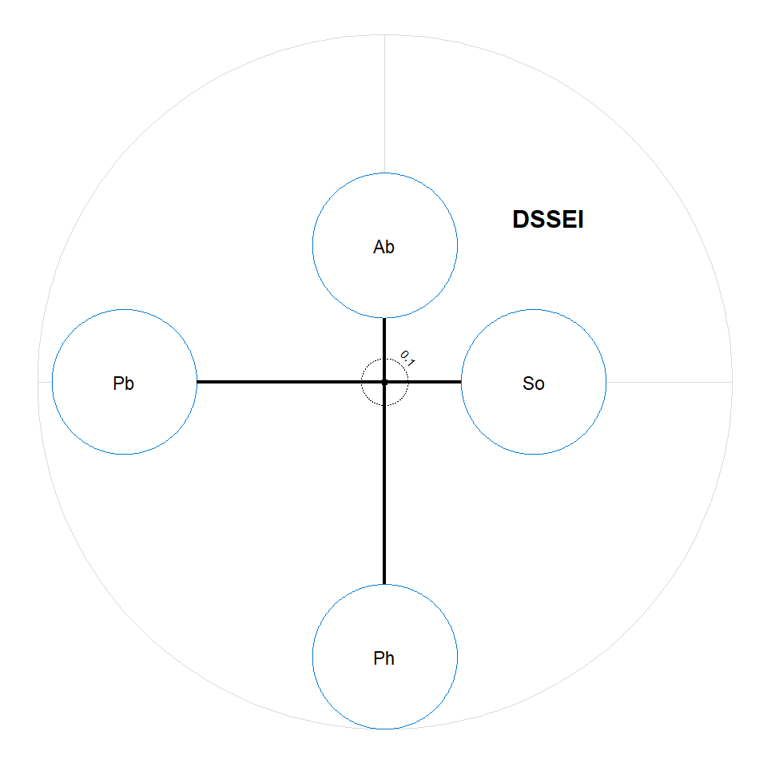

```r
mychart
```

#### 4.13. Special options for nested charts

Due to the complexity one should not rely on default values too much:

```r
mychart <- nested_chart(data = self_confidence)
```

```
#> Facet circle radius set to 0.211 based on the data.
#> cor_spacing set to 0.193 based on the data.
#> Relative scaling set to 3.78 based on the data.
#> Axis tick set to 0.1 based on the data.
#> dist_construct_label set to 0.5 based on the data.
```

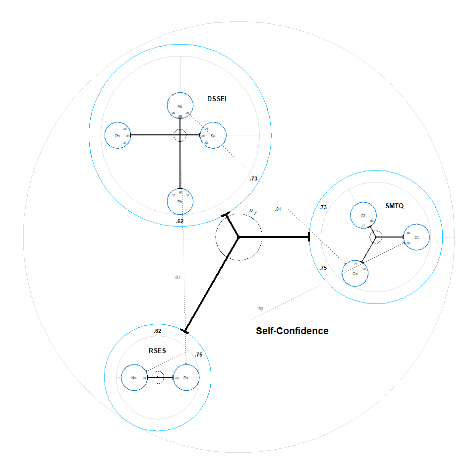

```r
mychart
```

There are four important options specific to nested charts: `relative_scaling =`, `xarrows =`, `subrotate_... =`, and `cor_spacing =`

The axis scaling within the nested facet charts is potentially different to the global axis scaling, by exactly the factor of `relative_scaling =`. This can be seen from the axis tick marks (small dotted circles), which always indicate the same value. `relative_scaling = 1` is desirable for intuitive understanding. Nevertheless, `relative_scaling =` should be large enough to avoid circle overlap.

```
#> Facet circle radius set to 0.211 based on the data.
#> cor_spacing set to 0.193 based on the data.
#> dist_construct_label set to 0.5 based on the data.
```

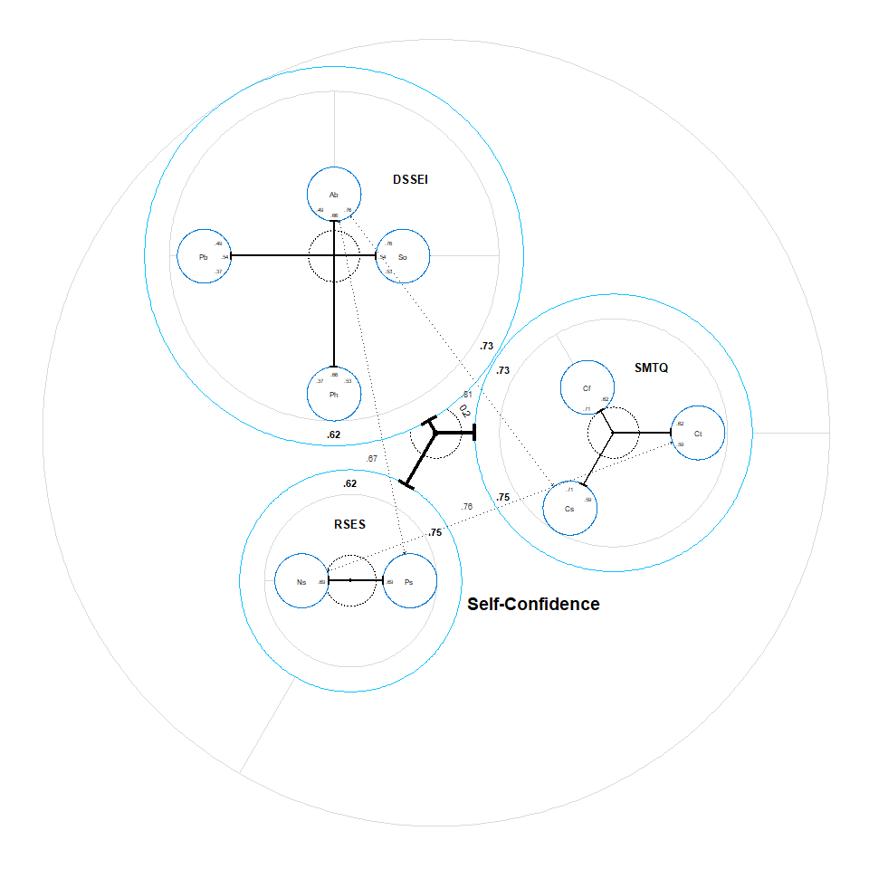

```r
# all axes have the same scaling
nested_chart(self_confidence, relative_scaling = 1, tick = 0.2, rotate_tick_label = -.2)
```

```
#> Facet circle radius set to 0.211 based on the data.
#> cor_spacing set to 0.193 based on the data.
#> dist_construct_label set to 0.5 based on the data.
```

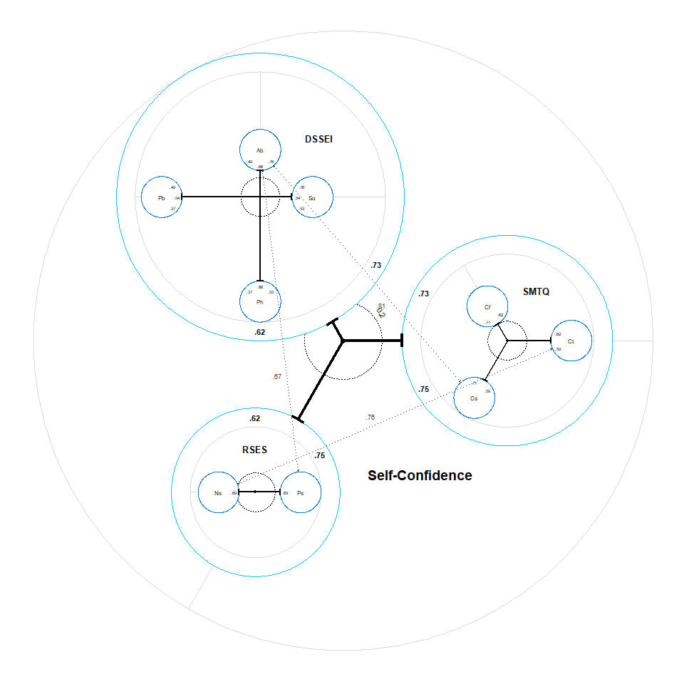

```r
# the global axis is twice as large (see dotted circles)
nested_chart(self_confidence, relative_scaling = 2, tick = 0.2, rotate_tick_label = -.2)
```

In this particular case, the facet circles could be larger, including the font sizes within:

```r
mychart <- nested_chart(
  data = self_confidence,
  subradius = .5,
  size_facet_labels = 2,
  size_cor_labels_inner = 1.5)
```

```
#> cor_spacing set to 0.28 based on the data.
#> Relative scaling set to 5.97 based on the data.
#> Axis tick set to 0.1 based on the data.
#> dist_construct_label set to 0.5 based on the data.
```

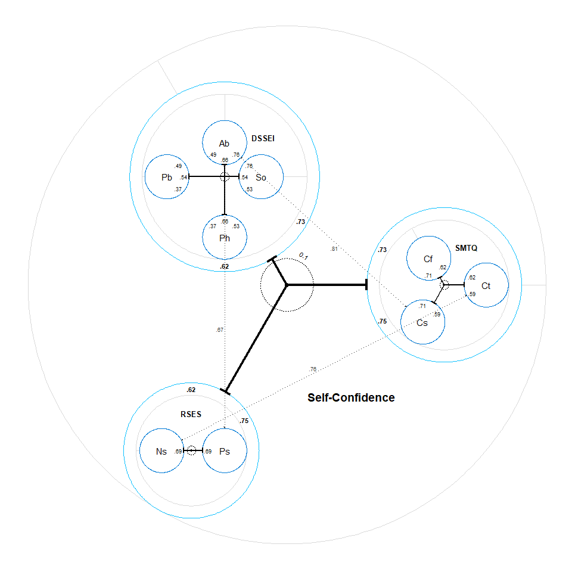

```r
mychart
```

Note how the dynamic default for `relative_scaling =` adapted to the changes, because the test circles became larger, due to the changes to `subradius =` .

The addition of correlation arrows between facets of different tests is indicated by the IPV authors as sensible, when the correlation between these facets exceed the correlation between the respective tests. The three arrows in the current example can also be omitted in the display:

```r
mychart <- nested_chart(
  data = self_confidence,
  subradius = .5,
  size_facet_labels = 2,
  size_cor_labels_inner = 1.5,
  xarrows = FALSE)
```

```
#> cor_spacing set to 0.28 based on the data.
#> Relative scaling set to 5.97 based on the data.
#> Axis tick set to 0.1 based on the data.
#> dist_construct_label set to 0.5 based on the data.
```

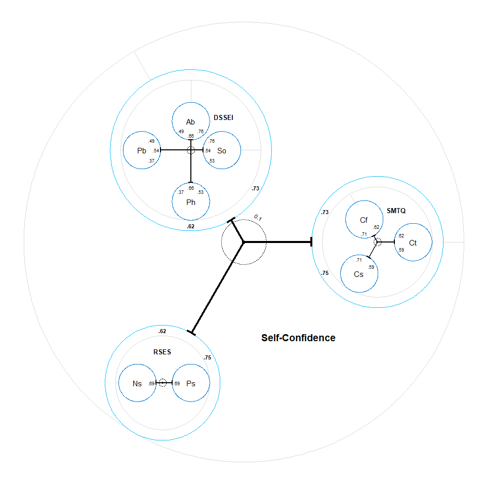

```r
mychart
```

The column names of the data frame providing the data for the arrows need to match the example.

Note that `ipv_est()` generates the data frame for these arrows automatically.

The arrows create a lot of overlap and make the chart look messy. This problem can be solved by rotating each of the nested facet charts, so the facets connected by arrows are oriented towards the center. Furthermore, the construct label should be moved out of harms way, as well as the test label of the SMTQ.

```r
mychart <- nested_chart(
  data = self_confidence,
  subradius = .5,
  size_facet_labels = 2,
  size_cor_labels_inner = 1.5,
  subrotate_degrees = c(180, 270, 90),
  dist_construct_label = .7,
  rotate_test_labels_degrees = c(0, 120, 0))
```

```
#> cor_spacing set to 0.28 based on the data.
#> Relative scaling set to 5.97 based on the data.
#> Axis tick set to 0.1 based on the data.
```

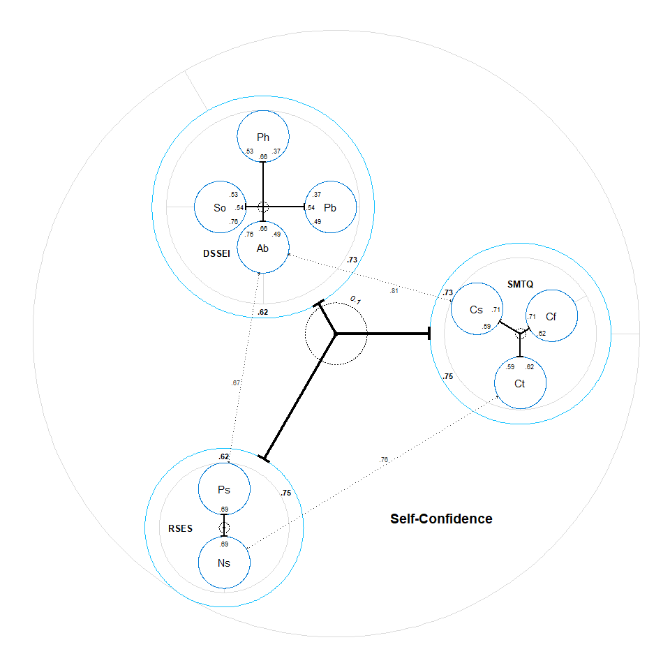

```r
mychart
```

The `cor_spacing =` refers to the ring around the nested facet charts for each test, in which the correlations between the tests are displayed. It should be large enough for the correlation labels, but not too large to skew proportions. If the correlations are omitted (`cor_labels_tests = FALSE`), this ring is also omitted:

```r
mychart <- nested_chart(
  data = self_confidence,
  subradius = .5,
  size_facet_labels = 2,
  size_cor_labels_inner = 1.5,
  subrotate_degrees = c(180, 270, 90),
  dist_construct_label = .7,
  rotate_test_labels_degrees = c(0, 120, 0),
  cor_labels_tests = FALSE)
```

```
#> Relative scaling set to 5.05 based on the data.
#> Axis tick set to 0.1 based on the data.
```

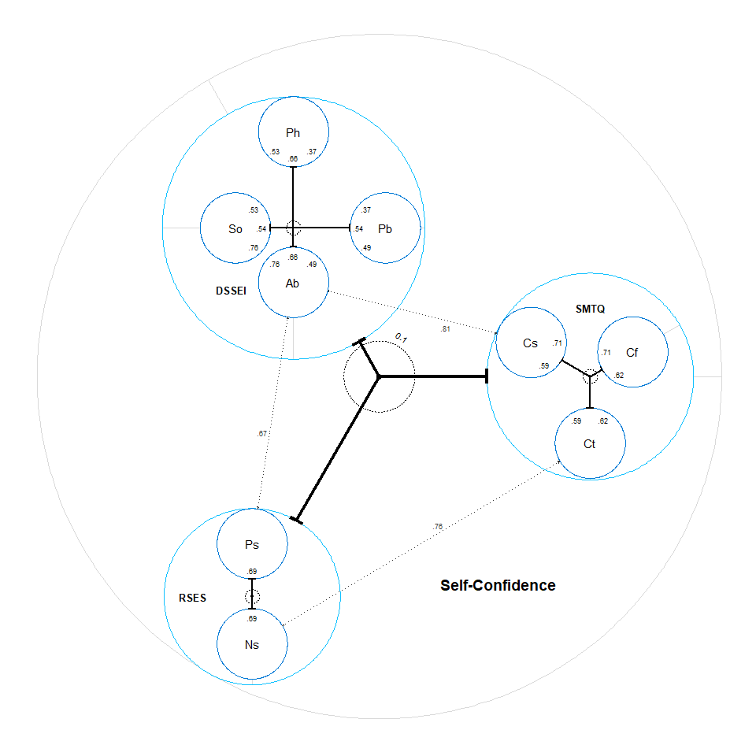

```r
mychart
```

Color can be chosen for the global and the nested level independently. Increasing the line thickness makes the colors more visible.

```r
mychart <- nested_chart(
  data = self_confidence,
  subradius = .5,
  size_facet_labels = 2,
  size_cor_labels_inner = 1.5,
  subrotate_degrees = c(180, 270, 90),
  dist_construct_label = .7,
  rotate_construct_label_degrees = -15,
  rotate_test_labels_degrees = c(0, 120, 0),
  size_construct_label = 1.3,
  size_test_labels = 1.2,
  width_circles_inner = 1.2,
  width_circles = 1.2,
  width_axes_inner = 1.2,
  width_axes = 1.2)
```

```
#> cor_spacing set to 0.28 based on the data.
#> Relative scaling set to 5.97 based on the data.
#> Axis tick set to 0.1 based on the data.
```

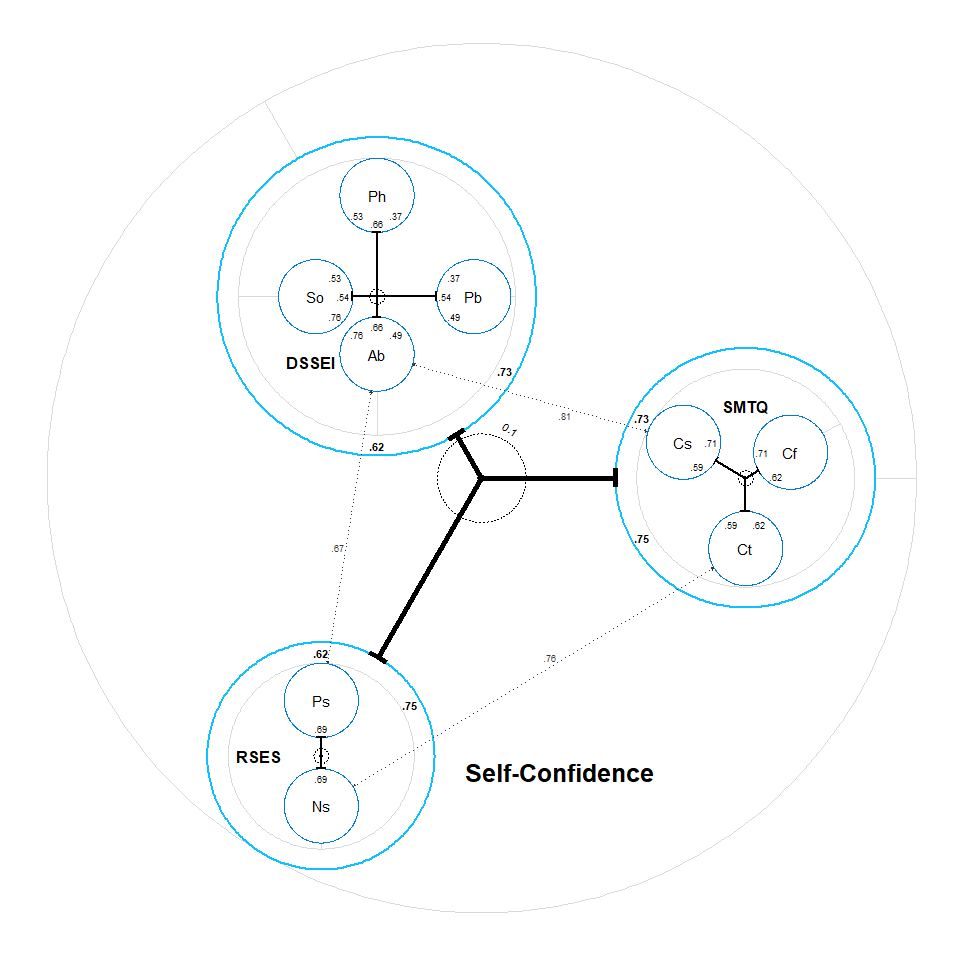

```r
mychart
```

## Object structure within the package

This is an example of the data format of the class “IPV”, which is required for the use of the chart functions and produced by `ipv_est()`:

```r
str(self_confidence, 2)
```

```
#> List of 2
#>  $ est   :List of 2
#>   ..$ global:List of 2
#>   ..$ tests :List of 3
#>  $ xarrow:'data.frame':  3 obs. of  5 variables:
#>   ..$ test1 : chr [1:3] "DSSEI" "DSSEI" "SMTQ"
#>   ..$ facet1: chr [1:3] "Ab" "Ab" "Ct"
#>   ..$ test2 : chr [1:3] "RSES" "SMTQ" "RSES"
#>   ..$ facet2: chr [1:3] "Ps" "Cs" "Ns"
#>   ..$ value : chr [1:3] ".67" ".81" ".76"
#>  - attr(*, "class")= chr [1:2] "IPV" "list"
```

```r
self_confidence$tests$RSES
```

[output not shown]

Note, that `factor` refers to an item pool, that was divided into subpools (`subfactor`s). In this case, `factor` refers to the Rosenberg Self-Esteem Scale, a test that can be divided in two facets: Positive Self-Esteem (Ps), and Negative Self-Esteem (Ns), which was reversed here. As seen below, the same data structure applies on the global level, with `factor` referring to the overall self-confidence item pool, comprising the three tests (`subfactor`s) RSES, SMTQ, and DSSEI.

```r
self_confidence$global
```

[output not shown]

`cd` is short for center distance
$$\begin{equation}
cd_i = \frac{\lambda^2_{is}}{\lambda^2_{ig}} -1
\end{equation}$$
while `mean_cd` is the mean center distance of the items of a facet or test. `aggregate_cd` is the center distance of a facet or test as a whole (see `cd_method`). Furthermore, the matrix of latent correlations between `subfactor`s is given as a second item of the list.

There is a raw variant (`$est_raw` in the output of `ipv_est`) of this, providing factor loadings instead of center distances.

## Appendix

### 2. Read existing estimates (alternative Workflow)

**Using `ipv_est()` will take less effort than estimating the models yourself and reading in the estimates. For this reason, it is recommended.** On the other hand, reading in existing estimates provides you with additional options during model estimation, or the ability to use published estimates without access to the raw data.

Regardless of the input mode, you will need to provide:

- the names of all latent variables and items
- the factor loadings of the SEMs
- the latent correlations between the factors within the SEMs.

To spare you the task of formatting estimates by hand, there are two automated input pathways. You can either use excel files or the manual input function. In both cases, center distances are calculated automatically and the estimates are automatically checked for (obvious) errors. Negative center distances are always set to zero before mean center distances are calculated.

#### … using estimates from within R

These functions allow you to reduce the manual work to a minimum. They are especially useful, when your SEM estimates are already in your R environment (e.g. because you read them from a .csv file). The functions `input_manual_nested()` and `input_manual_simple()` allow you to feed in vectors of factor loadings, item names, etc. The correct format for plotting is then generated automatically. Run `input_manual_process()` on the result, to automatically calculate center distances.  
This is an example, where all estimates are put in completely manually for demonstration purposes:

```r
mydata <- input_manual_simple(
test_name = "RSES",
facet_names = c("Ns", "Ps"),
items_per_facet = 5,
item_names = c(
  2, 5, 6, 8, 9,
  1, 3, 4, 7, 10),
test_loadings = c(
  .5806, .5907, .6179, .5899, .6559,
  .6005, .4932, .4476, .5033, .6431),
facet_loadings = c(
  .6484, .6011, .6988, .6426, .6914,
  .6422, .5835, .536, .5836, .6791),
correlation_matrix = matrix(
  data = c(1, .69,
           .69, 1),
  nrow = 2,
  ncol = 2))
mydata
```

```
#> $fls
#>    factor subfactor item factor_loading subfactor_loading
#> 1    RSES        Ns    2         0.5806            0.6484
#> 2    RSES        Ns    5         0.5907            0.6011
#> 3    RSES        Ns    6         0.6179            0.6988
#> 4    RSES        Ns    8         0.5899            0.6426
#> 5    RSES        Ns    9         0.6559            0.6914
#> 6    RSES        Ps    1         0.6005            0.6422
#> 7    RSES        Ps    3         0.4932            0.5835
#> 8    RSES        Ps    4         0.4476            0.5360
#> 9    RSES        Ps    7         0.5033            0.5836
#> 10   RSES        Ps   10         0.6431            0.6791
#>
#> $cors
#>      Ns   Ps
#> Ns 1.00 0.69
#> Ps 0.69 1.00
```

```r
input_manual_process(mydata)
```

```
#> $est
#> $est$global
#> $est$global$cds
#>    factor subfactor    item cd mean_cd aggregate_cd
#> 1    RSES      RSES  RSES.2  0       0            0
#> 2    RSES      RSES  RSES.5  0       0            0
#> 3    RSES      RSES  RSES.6  0       0            0
#> 4    RSES      RSES  RSES.8  0       0            0
#> 5    RSES      RSES  RSES.9  0       0            0
#> 6    RSES      RSES  RSES.1  0       0            0
#> 7    RSES      RSES  RSES.3  0       0            0
#> 8    RSES      RSES  RSES.4  0       0            0
#> 9    RSES      RSES  RSES.7  0       0            0
#> 10   RSES      RSES RSES.10  0       0            0
#>
#> $est$global$cors
#>      RSES
#> RSES    1
#>
#>
#> $est$tests
#> $est$tests$RSES
#> $est$tests$RSES$cds
#>    factor subfactor item         cd   mean_cd aggregate_cd
#> 1    RSES        Ns    2 0.24718807 0.1719081    0.1706512
#> 2    RSES        Ns    5 0.03552244 0.1719081    0.1706512
#> 3    RSES        Ns    6 0.27899664 0.1719081    0.1706512
#> 4    RSES        Ns    8 0.18665548 0.1719081    0.1706512
#> 5    RSES        Ns    9 0.11117763 0.1719081    0.1706512
#> 6    RSES        Ps    1 0.14370647 0.2874100    0.2521100
#> 7    RSES        Ps    3 0.39970201 0.2874100    0.2521100
#> 8    RSES        Ps    4 0.43400090 0.2874100    0.2521100
#> 9    RSES        Ps    7 0.34454922 0.2874100    0.2521100
#> 10   RSES        Ps   10 0.11509134 0.2874100    0.2521100
#>
#> $est$tests$RSES$cors
#>      Ns   Ps
#> Ns 1.00 0.69
#> Ps 0.69 1.00
#>
```

[output cut: 36 more lines]

```
#> 10   RSES        Ps   10         0.6431            0.6791
#>
#> $est_raw$tests$RSES$cors
#>      Ns   Ps
#> Ns 1.00 0.69
#> Ps 0.69 1.00
#>
#>
#>
#>
#> $xarrow
#> [1] NA
#>
#> attr(,"class")
#> [1] "IPV"  "list"
```

For nested cases, use the function `input_manual_nested()`, and add the individual tests using `input_manual_simple()`. Then you can run `input_manual_processs()` as in the simple case. You can find a (lengthy) example below.

#### … using Excel files

Excel files have the advantage that you can simply copy and paste your SEM estimates into spreadsheets and the input function of the IPV package (`input_excel()`) does the rest. The files need to be structured as in the example, that you can find here:

```r
system.file("extdata", "IPV_global.xlsx", package = "IPV", mustWork = TRUE)
system.file("extdata", "IPV_DSSEI.xlsx", package = "IPV", mustWork = TRUE)
system.file("extdata", "IPV_SMTQ.xlsx", package = "IPV", mustWork = TRUE)
system.file("extdata", "IPV_RSES.xlsx", package = "IPV", mustWork = TRUE)
```

As you can see, there is a file for each test, and a global file. You might want to use a copy as your template, so you can just fill in your values. Open a file to see how it works.

On sheet 1 you need to provide the factor loadings from your SEM estimation results, on sheet 2 you need to provide the named and complete latent correlation matrix. On sheet 1, “factor” contains a single factor name and “factor_loading” the factor loadings of items on that factor (not squared). “subfactor” contains the names of grouped factors and “subfactor_loading” the factor loadings of items on these factors (not squared). “item” contains the item names. Therefore, each row contains the full information on the respective item.  
Read these excel sheets using input_excel. In the example:

```r
global <- system.file("extdata", "IPV_global.xlsx", package = "IPV", mustWork = TRUE)
tests <- c(system.file("extdata", "IPV_DSSEI.xlsx", package = "IPV", mustWork = TRUE),
           system.file("extdata", "IPV_SMTQ.xlsx", package = "IPV", mustWork = TRUE),
           system.file("extdata", "IPV_RSES.xlsx", package = "IPV", mustWork = TRUE))
mydata <- input_excel(global = global, tests = tests)
```

```
#> Negative center distance adjusted to 0
#> Negative center distance adjusted to 0
#> Negative center distance adjusted to 0
```

The data will be prepared automatically, including the calculation of center distances. If any factor loading is below .1 or any center distance below 0, it is set to that value and a warning or message is displayed. IPV does not allow negative factor loadings, which is indicated by an error. If possible, recode your data appropriately.

#### Mix tests with and without facets

In nested charts, tests do not need to have facets. If you use input by excel, use `NA` instead of providing a file name.

```r
global <- system.file("extdata", "IPV_global.xlsx", package = "IPV", mustWork = TRUE)
tests <- c(system.file("extdata", "IPV_DSSEI.xlsx", package = "IPV", mustWork = TRUE),
           system.file("extdata", "IPV_SMTQ.xlsx", package = "IPV", mustWork = TRUE),
           NA)
mydata <- input_excel(global = global, tests = tests)
```

If you use manual input, do not provide data on facetless tests with `input_manual_simple()`. Any further treatment of facetless tests is handled automatically.

#### Manual input in nested cases - example

Note that all values that are put in manually for presentation purposes here could be read from an arbitrarily formatted R object. Copying values manually from another source is error-prone and therefore not recommended.

```r
# first the global level
mydata <- input_manual_nested(
  construct_name = "Self-Confidence",
  test_names = c("DSSEI", "SMTQ", "RSES"),
  items_per_test = c(20, 14, 10),
  item_names = c(
     1,  5,  9, 13, 17, # DSSEI
     3,  7, 11, 15, 19, # DSSEI
    16,  4, 12,  8, 20, # DSSEI
     2,  6, 10, 14, 18, # DSSEI
    11, 13, 14,  1,  5,  6, # SMTQ
     3, 10, 12,  8, # SMTQ
     7,  2,  4,  9, # SMTQ
     1,  3,  4,  7, 10, # RSES
     2,  5,  6,  8,  9), # RSES
  construct_loadings = c(
    .5189, .6055, .618 , .4074, .4442,
    .5203, .2479, .529 , .554 , .5144,
    .3958, .5671, .5559, .4591, .4927,
    .3713, .5941, .4903, .5998, .6616,
    .4182, .2504, .4094, .3977, .5177, .4603,
    .3271, .261 , .3614, .4226,
    .2076, .3375, .5509, .3495,
    .5482, .4627, .4185, .4185, .5319,
    .4548, .4773, .4604, .4657, .4986),
  test_loadings = c(
    .5694, .6794, .6615, .4142, .4584, # DSSEI
    .5554, .2165, .5675, .5649, .4752, # DSSEI
    .443 , .6517, .6421, .545 , .5266, # DSSEI
    .302 , .6067, .5178, .5878, .6572, # DSSEI
    .4486, .3282, .4738, .4567, .5986, .5416, # SMTQ
    .3602, .2955, .3648, .4814, # SMTQ
    .2593, .4053, .61  , .4121, # SMTQ
    .6005, .4932, .4476, .5033, .6431, # RSES
    .5806, .5907, .6179, .5899, .6559), # RSES
  correlation_matrix = matrix(
    data = c(
      1 , .73, .62,
      .73, 1, .75,
      .62, .75, 1),
    nrow = 3,
    ncol = 3))

# then add tests individually
# test 1
mydata$tests$RSES <- input_manual_simple(
  test_name = "RSES",
  facet_names = c("Ns", "Ps"),
  items_per_facet = c(5, 5),
  item_names = c(
    2, 5, 6, 8,  9,
    1, 3, 4, 7, 10),
  test_loadings = c(
    .5806, .5907, .6179, .5899, .6559,
    .6005, .4932, .4476, .5033, .6431),
  facet_loadings = c(
    .6484, .6011, .6988, .6426, .6914,
    .6422, .5835, .536, .5836, .6791),
  correlation_matrix = matrix(
    data = c(
      1, .69,
      .69, 1),
    nrow = 2,
    ncol = 2))
# test 2
mydata$tests$DSSEI <- input_manual_simple(
  test_name = "DSSEI",
  facet_names = c("Ab", "Pb", "Ph", "So"),
  items_per_facet = 5,
  item_names = c(
    2, 6, 10, 14, 18,
    16, 4, 12, 8, 20,
    3, 7, 11, 15, 19,
    1, 5, 9, 13, 17),
  test_loadings = c(
    .302 , .6067, .5178, .5878, .6572,
    .443 , .6517, .6421, .545 , .5266,
    .5554, .2165, .5675, .5649, .4752,
    .5694, .6794, .6615, .4142, .4584),
  facet_loadings = c(
    .3347, .6537, .6078, .684 , .735 ,
    .6861, .8746, .7982, .7521, .6794,
    .7947, .3737, .819 , .7099, .5785,
    .7293, .8284, .7892, .3101, .4384),
  correlation_matrix = matrix(
    data = c(
      1, .49, .66, .76,
      .49, 1, .37, .54,
      .66, .37, 1, .53,
      .76, .54, .53, 1),
    nrow = 4,
    ncol = 4))
# test 3
mydata$tests$SMTQ <- input_manual_simple(
  test_name = "SMTQ",
  facet_names = c("Cf", "Cs", "Ct"),
  items_per_facet = c(6, 4, 4),
  item_names = c(
    11, 13, 14, 1, 5, 6,
    3, 10, 12, 8,
    7, 2, 4, 9),
  test_loadings = c(
    .4486, .3282, .4738, .4567, .5986, .5416,
    .3602, .2955, .3648, .4814,
    .2593, .4053, .61  , .4121),
  facet_loadings = c(
    .4995, .3843, .5399, .4562, .6174, .6265,
    .4601, .3766, .4744, .5255,
    .3546, .5038, .7429, .4342),
  correlation_matrix = matrix(
    data = c(
      1, .71, .62,
      .71, 1, .59,
      .62, .59, 1),
    nrow = 3,
    ncol = 3))

# finally process (as in a simple case)
my_processed_data <- input_manual_process(mydata)
```

```
#> Negative center distance adjusted to 0
#> Negative center distance adjusted to 0
#> Negative center distance adjusted to 0
```

```r
my_processed_data
```

```
#> $est
#> $est$global
#> $est$global$cds
#>             factor subfactor     item         cd   mean_cd aggregate_cd
#> 1  Self-Confidence     DSSEI  DSSEI.1 0.20411394 0.1327392    0.1135489
#> 2  Self-Confidence     DSSEI  DSSEI.5 0.25899148 0.1327392    0.1135489
#> 3  Self-Confidence     DSSEI  DSSEI.9 0.14573122 0.1327392    0.1135489
#> 4  Self-Confidence     DSSEI DSSEI.13 0.03366102 0.1327392    0.1135489
#> 5  Self-Confidence     DSSEI DSSEI.17 0.06495709 0.1327392    0.1135489
#> 6  Self-Confidence     DSSEI  DSSEI.3 0.13947316 0.1327392    0.1135489
#> 7  Self-Confidence     DSSEI  DSSEI.7 0.00000000 0.1327392    0.1135489
#> 8  Self-Confidence     DSSEI DSSEI.11 0.15085441 0.1327392    0.1135489
#> 9  Self-Confidence     DSSEI DSSEI.15 0.03973729 0.1327392    0.1135489
#> 10 Self-Confidence     DSSEI DSSEI.19 0.00000000 0.1327392    0.1135489
#> 11 Self-Confidence     DSSEI DSSEI.16 0.25272537 0.1327392    0.1135489
#> 12 Self-Confidence     DSSEI  DSSEI.4 0.32061476 0.1327392    0.1135489
#> 13 Self-Confidence     DSSEI DSSEI.12 0.33417252 0.1327392    0.1135489
#> 14 Self-Confidence     DSSEI  DSSEI.8 0.40921877 0.1327392    0.1135489
#> 15 Self-Confidence     DSSEI DSSEI.20 0.14234316 0.1327392    0.1135489
#> 16 Self-Confidence     DSSEI  DSSEI.2 0.00000000 0.1327392    0.1135489
#> 17 Self-Confidence     DSSEI  DSSEI.6 0.04286690 0.1327392    0.1135489
#> 18 Self-Confidence     DSSEI DSSEI.10 0.11532209 0.1327392    0.1135489
#> 19 Self-Confidence     DSSEI DSSEI.14 0.00000000 0.1327392    0.1135489
#> 20 Self-Confidence     DSSEI DSSEI.18 0.00000000 0.1327392    0.1135489
#> 21 Self-Confidence      SMTQ  SMTQ.11 0.15066918 0.3341203    0.3027064
#> 22 Self-Confidence      SMTQ  SMTQ.13 0.71794203 0.3341203    0.3027064
#> 23 Self-Confidence      SMTQ  SMTQ.14 0.33935109 0.3341203    0.3027064
#> 24 Self-Confidence      SMTQ   SMTQ.1 0.31871468 0.3341203    0.3027064
#> 25 Self-Confidence      SMTQ   SMTQ.5 0.33695594 0.3341203    0.3027064
#> 26 Self-Confidence      SMTQ   SMTQ.6 0.38444390 0.3341203    0.3027064
#> 27 Self-Confidence      SMTQ   SMTQ.3 0.21262447 0.3341203    0.3027064
#> 28 Self-Confidence      SMTQ  SMTQ.10 0.28184040 0.3341203    0.3027064
#> 29 Self-Confidence      SMTQ  SMTQ.12 0.01890422 0.3341203    0.3027064
#> 30 Self-Confidence      SMTQ   SMTQ.8 0.29763690 0.3341203    0.3027064
#> 31 Self-Confidence      SMTQ   SMTQ.7 0.56009245 0.3341203    0.3027064
#> 32 Self-Confidence      SMTQ   SMTQ.2 0.44213412 0.3341203    0.3027064
#> 33 Self-Confidence      SMTQ   SMTQ.4 0.22606678 0.3341203    0.3027064
#> 34 Self-Confidence      SMTQ   SMTQ.9 0.39030751 0.3341203    0.3027064
#> 35 Self-Confidence      RSES   RSES.1 0.19990803 0.4685707    0.4677902
#> 36 Self-Confidence      RSES   RSES.3 0.13617999 0.4685707    0.4677902
```

[output cut: 222 more lines]

```
#> 10   RSES        Ps   10         0.6431            0.6791
#>
#> $est_raw$tests$RSES$cors
#>      Ns   Ps
#> Ns 1.00 0.69
#> Ps 0.69 1.00
#>
#>
#>
#>
#> $xarrow
#> [1] NA
#>
#> attr(,"class")
#> [1] "IPV"  "list"
```